# Analyzing change in the British English Adjective Amplifier System based on the Old Baily Corpus (Part 1)

Martin Schweinberger

2021-05-20

This document reports the analysis of the use of adjective amplifiers in British English based on the [Old Bailey Corpus (Version 2.0)](https://fedora.clarin-d.uni-saarland.de/oldbailey/).

# 1 Introduction

We will now begin with the analysis. In a first step, the session is prepared by setting options and activating packages.

```r
# load packages
library(tidyverse)  # data processing
library(tidyr)      # data processing
library(knitr)      # table vis
library(kableExtra) # table vis
library(DT)         # table vis
library(usethis)    # git
library(textreadr)  # reah xml
library(textdata)   # sentiment analysis
library(quanteda)   # concordancing
library(hunspell)   # spelling
library(udpipe)     # pos tagging
# set options
options(stringsAsFactors = F)
options(scipen = 999)
options(max.print=10000)
# specify paths
corpuspath <- "D:\\Uni\\Korpora\\Original\\OldBaileyCorpus\\OldBaileyCorpus2\\OldBaileyCorpus2\\OBC2"
# define corpus files
corpusfiles = list.files(path = corpuspath, pattern = "POS", all.files = T,
                         full.names = T, recursive = F, ignore.case = T,
                         include.dirs = F)
# for testing purposes we only use the first 5 files
corpusfiles <- corpusfiles[1:5]
# inspect
head(corpusfiles)
```

```
## [1] "D:\\Uni\\Korpora\\Original\\OldBaileyCorpus\\OldBaileyCorpus2\\OldBaileyCorpus2\\OBC2/OBC2POS-17200427.xml"
## [2] "D:\\Uni\\Korpora\\Original\\OldBaileyCorpus\\OldBaileyCorpus2\\OldBaileyCorpus2\\OBC2/OBC2POS-17200602.xml"
## [3] "D:\\Uni\\Korpora\\Original\\OldBaileyCorpus\\OldBaileyCorpus2\\OldBaileyCorpus2\\OBC2/OBC2POS-17200907.xml"
## [4] "D:\\Uni\\Korpora\\Original\\OldBaileyCorpus\\OldBaileyCorpus2\\OldBaileyCorpus2\\OBC2/OBC2POS-17201012.xml"
## [5] "D:\\Uni\\Korpora\\Original\\OldBaileyCorpus\\OldBaileyCorpus2\\OldBaileyCorpus2\\OBC2/OBC2POS-17210113.xml"
```

# 2 Data Processing

Load and process data

```r
# load and start processing corpus
obc <- sapply(corpusfiles, function(x) {
  x <- textreadr::read_xml(x)
  x <- paste0(x, collapse = " ")
  x <- stringr::str_remove_all(x, "\n")
  x <- stringr::str_squish(x)
  x <- stringr::str_replace_all(x, " ([:punct:])", "\\1")
} )
# inspect
str(obc)
```

```
##  Named chr [1:5] "THE_AT PROCEEDINGS_NN2 ON_II THE_AT KING_NN1's_GE Commission_NN1 of_IO the_AT Peace_NN1,_, AND_CC Oyer_NN1 and_"| __truncated__ ...
##  - attr(*, "names")= chr [1:5] "D:\\Uni\\Korpora\\Original\\OldBaileyCorpus\\OldBaileyCorpus2\\OldBaileyCorpus2\\OBC2/OBC2POS-17200427.xml" "D:\\Uni\\Korpora\\Original\\OldBaileyCorpus\\OldBaileyCorpus2\\OldBaileyCorpus2\\OBC2/OBC2POS-17200602.xml" "D:\\Uni\\Korpora\\Original\\OldBaileyCorpus\\Ol…
```

## Extract meta information

```r
# extract file names
File <- names(obc)
File <- stringr::str_remove_all(File, ".*/")
File <- gsub(".xml", "", File)
# extract raw text
Text <- as.vector(unlist(obc))
# extract date
Date <- stringr::str_extract_all(File, "POS-[0-9]{4,4}") %>%
  stringr::str_remove_all("POS-")
# clean text
CleanText <- Text %>%
  stringr::str_remove_all(fixed("\\")) %>%
  stringr::str_remove_all("_[:graph:]") %>%
  tolower() %>%
  stringr::str_squish()
# extract wordcount
words <- stringr::str_count(CleanText, " ")+1
# create an id
docname <- paste0("text", 1:length(Text))
# combine elements into a data frame
obcdf <- data.frame(docname, File, Date, Text, CleanText, words)
# inspect
nrow(obcdf)
```

```
## [1] 5
```

Save data to disc

```r
# save data
base::saveRDS(obcdf, file = here::here("data", "obcdf_raw.rda"))
# reload data
obcdf  <- base::readRDS(file = here::here("data", "obcdf_raw.rda"))
```

## Concordancing

```r
# generate kwic
concobc <- quanteda::kwic(obcdf$Text,
                         pattern = "[:alnum:]{1,}_JJ[:alnum:]{0,3}",
                         window = 15,
                         valuetype = "regex") %>%
  as.data.frame() %>%
  dplyr::select(-pattern, -from, -to)
# inspect
head(concobc)
```

```
##   docname
## 1   text1
## 2   text1
## 3   text1
## 4   text1
## 5   text1
## 6   text1
##                                                                                                                            pre
## 1                             London_NP1 , _ , and_CC COUNTY_NN1 of_IO Middlesex_NP1 , _ , at_II Justice-Hall_NP1 in_II the_AT
## 2                                              MAJESTY_NN1 ' s_GE Reign_NN1 . _ . 6_MC May_NPM1 1720_MC . _ . BEFORE_CS the_AT
## 3                                                 ' s_GE Reign_NN1 . _ . 6_MC May_NPM1 1720_MC . _ . BEFORE_CS the_AT Right_JJ
## 4                         _NNU the_AT Goods_NN2 of_IO Job_NN1 Wicks_NN2 , _ , in_II the_AT Dwelling_NN1 House_NN1 of_IO the_AT
## 5           appeared_VVD that_CST the_AT Prisoner_NN1 was_VBDZ the_AT Prosecutor_NN1 ' s_GE Servant_NN1 ; _ ; and_CC his_APPGE
## 6 also_RR deposed_VVN that_CST he_PPHS1 confest_VVD he_PPHS1 had_VHD taken_VVN Tobacco_NN1 several_DA2 times_NNT2 . _ . The_AT
##         keyword
## 1        Old_JJ
## 2      Right_JJ
## 3 Honourable_JJ
## 4       said_JJ
## 5     fellow_JJ
## 6       said_JJ
##                                                                                                                                post
## 1                                                 Bayly_NP1 , _ , ON_II Wednesday_NPD1 , _ , Thursday_NPD1 and_CC Friday_NPD1 , _ ,
## 2                             Honourable_JJ Sir_NN1 GEORGE_NP1 THOROLD_NP1 , _ , Kt_NP1 and_CC Baronet_NN1 , _ , Lord_NN1 Mayor_NN1
## 3                                     Sir_NN1 GEORGE_NP1 THOROLD_NP1 , _ , Kt_NP1 and_CC Baronet_NN1 , _ , Lord_NN1 Mayor_NN1 of_IO
## 4                                                Job_NN1 Wicks_NN2 , _ , on_II the_AT 8th_MD of_IO April_NPM1 last_MD . _ . It_PPH1
## 5 Servant_NN1 deposed_VVN that_CST he_PPHS1 perceiving_VVG his_APPGE Pocket_NN1 to_TO stick_VVI out_RP , _ , searched_VVD him_PPHO1
## 6          Paper_NN1 of_IO Tobacco_NN1 was_VBDZ produced_VVN in_II Court_NN1 . _ . The_AT Jury_NN1 considering_II the_AT matter_NN1
```

```r
meta <- obcdf %>%
  dplyr::select(docname, File, Date, words)
# combine meta and kwic
ampobc <- dplyr::left_join(concobc, meta, by = "docname") %>%
  dplyr::mutate(id = 1:nrow(.))
# inspect
head(ampobc)
```

```
##   docname
## 1   text1
## 2   text1
## 3   text1
## 4   text1
## 5   text1
## 6   text1
##                                                                                                                            pre
## 1                             London_NP1 , _ , and_CC COUNTY_NN1 of_IO Middlesex_NP1 , _ , at_II Justice-Hall_NP1 in_II the_AT
## 2                                              MAJESTY_NN1 ' s_GE Reign_NN1 . _ . 6_MC May_NPM1 1720_MC . _ . BEFORE_CS the_AT
## 3                                                 ' s_GE Reign_NN1 . _ . 6_MC May_NPM1 1720_MC . _ . BEFORE_CS the_AT Right_JJ
## 4                         _NNU the_AT Goods_NN2 of_IO Job_NN1 Wicks_NN2 , _ , in_II the_AT Dwelling_NN1 House_NN1 of_IO the_AT
## 5           appeared_VVD that_CST the_AT Prisoner_NN1 was_VBDZ the_AT Prosecutor_NN1 ' s_GE Servant_NN1 ; _ ; and_CC his_APPGE
## 6 also_RR deposed_VVN that_CST he_PPHS1 confest_VVD he_PPHS1 had_VHD taken_VVN Tobacco_NN1 several_DA2 times_NNT2 . _ . The_AT
##         keyword
```

[output cut: 20 more lines]

Visualize distribution of files against `Date`

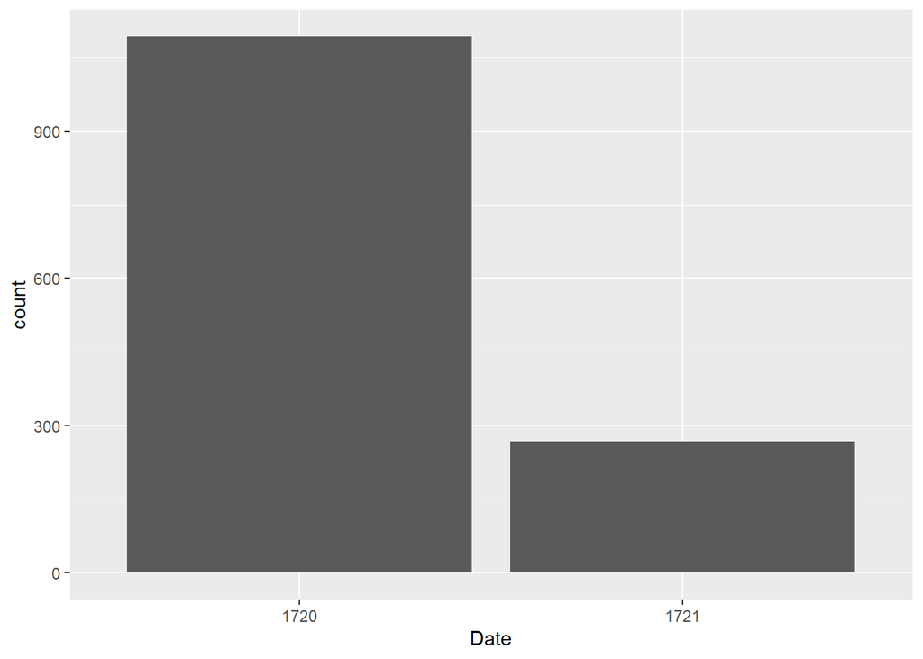

```r
ampobc %>%
  ggplot(aes(x = Date)) +
  geom_histogram(stat="count")
```

Save data to disc

```r
# save data
base::saveRDS(ampobc, file = here::here("data", "ampobc_raw.rda"))
# reload data
ampobc  <- base::readRDS(file = here::here("data", "ampobc_raw.rda"))
```

## Frequency

```r
# code freq of adj type by date category
ampobc <- ampobc %>%
  dplyr::mutate(adjective = tolower(keyword),
                adjective = str_remove_all(adjective, "_.*"),
                Datecat = Date %>%
                  as.numeric()) %>%
  dplyr::mutate(Datecat = dplyr::case_when(Datecat >= 1900 ~ "1900-1999",
                                           Datecat >= 1800 ~ "1800-1899",
                                           Datecat >= 1700 ~ "1700-1799",
                                           TRUE ~ "1600-1699")) %>%
  dplyr::group_by(Datecat, adjective) %>%
  dplyr::mutate(adjectiveN = n()) %>%
  dplyr::group_by(Datecat) %>%
  dplyr::mutate(adjectivesN = n()) %>%
  dplyr::mutate(frequency = round(adjectiveN/adjectivesN*1000, 5))
# inspect
head(ampobc)
```

```
## # A tibble: 6 x 13
## # Groups:   Datecat [1]
##   docname pre       keyword  post      File  Date  words    id adjective Datecat
##   <chr>   <chr>     <chr>    <chr>     <chr> <chr> <dbl> <int> <chr>     <chr>
## 1 text1   London_N~ Old_JJ   Bayly_NP~ OBC2~ 1720  11322     1 old       1700-1~
## 2 text1   MAJESTY_~ Right_JJ Honourab~ OBC2~ 1720  11322     2 right     1700-1~
## 3 text1   ' s_GE R~ Honoura~ Sir_NN1 ~ OBC2~ 1720  11322     3 honourab~ 1700-1~
## 4 text1   _NNU the~ said_JJ  Job_NN1 ~ OBC2~ 1720  11322     4 said      1700-1~
## 5 text1   appeared~ fellow_~ Servant_~ OBC2~ 1720  11322     5 fellow    1700-1~
## 6 text1   also_RR ~ said_JJ  Paper_NN~ OBC2~ 1720  11322     6 said      1700-1~
## # ... with 3 more variables: adjectiveN <int>, adjectivesN <int>,
## #   frequency <dbl>
```

Save data to disc

```r
# save data
base::saveRDS(ampobc, file = here::here("data", "ampobc_semi.rda"))
# reload data
ampobc  <- base::readRDS(file = here::here("data", "ampobc_semi.rda"))
```

## Syntactic Function

```r
# determine function
Function1 <- ampobc$post %>%
  stringr::str_squish() %>%
  tolower() %>%
  stringr::str_replace_all(" .*", "") %>%
  stringr::str_replace_all(".*_n.*", "Attributive") %>%
  stringr::str_replace_all(fixed("/."), "PUNCT") %>%
  stringr::str_replace_all(".*PUNCT.*", "Attributive")
Function2 <-  ampobc$post %>%
  stringr::str_squish() %>%
  tolower() %>%
  stringr::str_replace(" ", "") %>%
  stringr::str_replace_all(" .*", "") %>%
  stringr::str_replace_all(".*_n.*", "Attributive") %>%
  stringr::str_replace_all(fixed("/."), "PUNCT") %>%
  stringr::str_replace_all(".*PUNCT.*", "Attributive")
functiontb <- cbind(Function1, Function2)
# inspect
head(functiontb)
```

```
##      Function1       Function2
## [1,] "Attributive"   "Attributive"
## [2,] "honourable_jj" "Attributive"
## [3,] "Attributive"   "Attributive"
## [4,] "Attributive"   "Attributive"
## [5,] "Attributive"   "Attributive"
## [6,] "Attributive"   "Attributive"
```

## Check Amplifiers

not included: *quite*, *too*, and *well*.

```r
# define amplifiers
amplifiers <- c("absolutely", "actually", "aggressively", "amazingly", "appallingly", "awful",
                "awfully", "badly", "bloody", "certainly", "clearly", "complete", "dead", "completely",
                "considerably", "crazy", "decidedly", "definitely", "distinctly", "dreadfully",
                "enormously", "entirely", "especially", "exactly", "exceedingly", "exceptionally",
                "excruciatingly", "extraordinarily", "extremely", "fiercely", "firmly", "frightfully",
                "fucking", "fully", "genuinely", "greatly", "grossly", "heavily", "highly", "hopelessly",
                "horrendously", "hugely", "immediately", "immensely", "incredibly", "infinitely",
                "intensely", "irrevocably", "mad", "mega", "mighty", "most", "much", "obviously",
                "openly", "overwhelmingly", "particularly", "perfectly", "plenty", "positively",
                "precisely", "pretty", "profoundly", "purely", "real", "really", "remarkably", "seriously",
                "shocking", "significant", "significantly", "so", "specially", "specifically", "strikingly",
                "strongly", "substantially", "super", "surely", "terribly", "terrifically", "total",
                "totally", "traditionally", "true", "truly", "ultra", "utterly", "very", "viciously",
                "wholly", "wicked", "wildly")
```

```r
ampobc <- ampobc %>%
  dplyr::mutate(Function = dplyr::case_when(Function1 == "" |
                                              Function1 == "Attributive" |
                                              Function2 == "Attributive" ~ "Attributive",
                                            FALSE ~ "Predicative")) %>%
  # extract variant
  dplyr::mutate(Variant = tolower(pre),
                Variant = str_remove_all(Variant, ".* "),
                Variant = str_remove_all(Variant, "_.*"),
                Variant = ifelse(Variant %in% amplifiers, Variant, "Zero")) %>%
  # code amplification
  dplyr::mutate(Amplified = ifelse(Variant == "Zero", 0, 1))
# inspect
head(ampobc)
```

```
## # A tibble: 6 x 16
## # Groups:   Datecat [1]
##   docname pre       keyword  post      File  Date  words    id adjective Datecat
##   <chr>   <chr>     <chr>    <chr>     <chr> <chr> <dbl> <int> <chr>     <chr>
## 1 text1   London_N~ Old_JJ   Bayly_NP~ OBC2~ 1720  11322     1 old       1700-1~
## 2 text1   MAJESTY_~ Right_JJ Honourab~ OBC2~ 1720  11322     2 right     1700-1~
## 3 text1   ' s_GE R~ Honoura~ Sir_NN1 ~ OBC2~ 1720  11322     3 honourab~ 1700-1~
## 4 text1   _NNU the~ said_JJ  Job_NN1 ~ OBC2~ 1720  11322     4 said      1700-1~
## 5 text1   appeared~ fellow_~ Servant_~ OBC2~ 1720  11322     5 fellow    1700-1~
## 6 text1   also_RR ~ said_JJ  Paper_NN~ OBC2~ 1720  11322     6 said      1700-1~
## # ... with 6 more variables: adjectiveN <int>, adjectivesN <int>,
## #   frequency <dbl>, Function <chr>, Variant <chr>, Amplified <dbl>
```

## Code Priming

```r
# code priming
prim1 <- c(rep(0, 1), ampobc$Variant[1:length(ampobc$Variant)-1])
prim2 <- c(rep(0, 2), ampobc$Variant[1:(length(ampobc$Variant)-2)])
prim3 <- c(rep(0, 3), ampobc$Variant[1:(length(ampobc$Variant)-3)])
primtb <- cbind(ampobc$Variant, prim1, prim2, prim3)
# inspect
head(primtb)
```

```
##             prim1  prim2  prim3
## [1,] "Zero" "0"    "0"    "0"
## [2,] "Zero" "Zero" "0"    "0"
## [3,] "Zero" "Zero" "Zero" "0"
## [4,] "Zero" "Zero" "Zero" "Zero"
## [5,] "Zero" "Zero" "Zero" "Zero"
## [6,] "Zero" "Zero" "Zero" "Zero"
```

```r
ampobc$Priming <- as.vector(unlist(apply(primtb, 1, function(x){
  x <- ifelse(x[1]== "Zero" , "NoPrime",
              ifelse(x[1] == x[2] | x[1] == x[3] | x[1] == x[4], "Prime", "NoPrime"))
})))
# define forms that require removal
sups <- c(".*most.*", ".*more.*")
negs <- c(".*not.*", ".*never.*", ".*n't.*")
downtoners <- c(".*sort_.*", ".*kind_.*", ".* bit_.*", ".*somewhat.*", ".*fairly.*",
                ".*rather.*", ".*reasonably.*", ".*slightly.*", ".*comparatively.*", ".*semi.*",
                ".*relatively.*", ".*little.*", ".*somehow.*", ".*almost.*", ".*partly.*",
                ".*hardly.*", ".* less.*", ".*barely.*", ".* just_.*")
specialforms <- c(".* too.*", ".*quite.*")
PostContextdowntoners <- c(".*enough.*")
nonpropadj <- c("only", "much", "many", "cheaper", "cheaperr", "bests", "larger",
                "bst", "better", "bigger")
# check length of dataset
str(ampobc); head(ampobc); nrow(ampobc)
```

```
## grouped_df [1,359 x 17] (S3: grouped_df/tbl_df/tbl/data.frame)
##  $ docname    : chr [1:1359] "text1" "text1" "text1" "text1" ...
##  $ pre        : chr [1:1359] "London_NP1 , _ , and_CC COUNTY_NN1 of_IO Middlesex_NP1 , _ , at_II Justice-Hall_NP1 in_II the_AT" "MAJESTY_NN1 ' s_GE Reign_NN1 . _ . 6_MC May_NPM1 1720_MC . _ . BEFORE_CS the_AT" "' s_GE Reign_NN1 . _ . 6_MC May_NPM1 1720_MC . _ . BEFORE_CS the_AT Right_JJ" "_NNU th…
##  $ keyword    : chr [1:1359] "Old_JJ" "Right_JJ" "Honourable_JJ" "said_JJ" ...
##  $ post       : chr [1:1359] "Bayly_NP1 , _ , ON_II Wednesday_NPD1 , _ , Thursday_NPD1 and_CC Friday_NPD1 , _ ," "Honourable_JJ Sir_NN1 GEORGE_NP1 THOROLD_NP1 , _ , Kt_NP1 and_CC Baronet_NN1 , _ , Lord_NN1 Mayor_NN1" "Sir_NN1 GEORGE_NP1 THOROLD_NP1 , _ , Kt_NP1 and_CC Baronet_NN1 , _ , Lord_NN1 M…
##  $ File       : chr [1:1359] "OBC2POS-17200427" "OBC2POS-17200427" "OBC2POS-17200427" "OBC2POS-17200427" ...
##  $ Date       : chr [1:1359] "1720" "1720" "1720" "1720" ...
##  $ words      : num [1:1359] 11322 11322 11322 11322 11322 ...
##  $ id         : int [1:1359] 1 2 3 4 5 6 7 8 9 10 ...
##  $ adjective  : chr [1:1359] "old" "right" "honourable" "said" ...
##  $ Datecat    : chr [1:1359] "1700-1799" "1700-1799" "1700-1799" "1700-1799" ...
##  $ adjectiveN : int [1:1359] 22 21 9 30 2 30 159 32 21 1 ...
##  $ adjectivesN: int [1:1359] 1359 1359 1359 1359 1359 1359 1359 1359 1359 1359 ...
##  $ frequency  : num [1:1359] 16.19 15.45 6.62 22.08 1.47 ...
##  $ Function   : chr [1:1359] "Attributive" "Attributive" "Attributive" "Attributive" ...
##  $ Variant    : chr [1:1359] "Zero" "Zero" "Zero" "Zero" ...
##  $ Amplified  : num [1:1359] 0 0 0 0 0 0 0 0 0 0 ...
##  $ Priming    : chr [1:1359] "NoPrime" "NoPrime" "NoPrime" "NoPrime" ...
##  - attr(*, "groups")= tibble [1 x 2] (S3: tbl_df/tbl/data.frame)
##   ..$ Datecat: chr "1700-1799"
##   ..$ .rows  : list<int> [1:1]
##   .. ..$ : int [1:1359] 1 2 3 4 5 6 7 8 9 10 ...
##   .. ..@ ptype: int(0)
##   ..- attr(*, ".drop")= logi TRUE
```

```
## # A tibble: 6 x 17
## # Groups:   Datecat [1]
##   docname pre       keyword  post      File  Date  words    id adjective Datecat
##   <chr>   <chr>     <chr>    <chr>     <chr> <chr> <dbl> <int> <chr>     <chr>
## 1 text1   London_N~ Old_JJ   Bayly_NP~ OBC2~ 1720  11322     1 old       1700-1~
## 2 text1   MAJESTY_~ Right_JJ Honourab~ OBC2~ 1720  11322     2 right     1700-1~
## 3 text1   ' s_GE R~ Honoura~ Sir_NN1 ~ OBC2~ 1720  11322     3 honourab~ 1700-1~
## 4 text1   _NNU the~ said_JJ  Job_NN1 ~ OBC2~ 1720  11322     4 said      1700-1~
## 5 text1   appeared~ fellow_~ Servant_~ OBC2~ 1720  11322     5 fellow    1700-1~
## 6 text1   also_RR ~ said_JJ  Paper_NN~ OBC2~ 1720  11322     6 said      1700-1~
## # ... with 7 more variables: adjectiveN <int>, adjectivesN <int>,
## #   frequency <dbl>, Function <chr>, Variant <chr>, Amplified <dbl>,
## #   Priming <chr>
```

```
## [1] 1359
```

## Remove negated forms et al.

```r
# find items to be removed
supsidx <- unique(grep(paste(sups,collapse="|"), ampobc$pre, value=F))
negsidx <- unique(grep(paste(negs,collapse="|"), ampobc$pre, value=F))
downtonersidx <- unique(grep(paste(downtoners,collapse="|"), ampobc$pre, value=F))
specialformsidx <- unique(grep(paste(specialforms,collapse="|"), ampobc$pre, value=F))
PostContextdowntonersidx <- unique(grep(paste(PostContextdowntoners,collapse="|"), ampobc$PostContext, value=F))
nonpropadjidx <- unique(grep(paste(nonpropadj,collapse="|"), ampobc$Adjective, value=F))
# combine indices
idxs <- unique(c(supsidx, negsidx, downtonersidx, specialformsidx, PostContextdowntonersidx, nonpropadjidx))
# remove forms that require removal
ampobc <- ampobc[-idxs,]
# remove empty values
ampobc <- ampobc[!ampobc$Variant == "", ]
# inspect
head(ampobc)
```

```
## # A tibble: 6 x 17
## # Groups:   Datecat [1]
##   docname pre       keyword  post      File  Date  words    id adjective Datecat
##   <chr>   <chr>     <chr>    <chr>     <chr> <chr> <dbl> <int> <chr>     <chr>
## 1 text1   London_N~ Old_JJ   Bayly_NP~ OBC2~ 1720  11322     1 old       1700-1~
## 2 text1   MAJESTY_~ Right_JJ Honourab~ OBC2~ 1720  11322     2 right     1700-1~
## 3 text1   ' s_GE R~ Honoura~ Sir_NN1 ~ OBC2~ 1720  11322     3 honourab~ 1700-1~
## 4 text1   _NNU the~ said_JJ  Job_NN1 ~ OBC2~ 1720  11322     4 said      1700-1~
## 5 text1   appeared~ fellow_~ Servant_~ OBC2~ 1720  11322     5 fellow    1700-1~
## 6 text1   also_RR ~ said_JJ  Paper_NN~ OBC2~ 1720  11322     6 said      1700-1~
## # ... with 7 more variables: adjectiveN <int>, adjectivesN <int>,
## #   frequency <dbl>, Function <chr>, Variant <chr>, Amplified <dbl>,
## #   Priming <chr>
```

Save data to disc

```r
# save data
base::saveRDS(ampobc, file = here::here("data", "ampobc_woneg.rda"))
# reload data
ampobc  <- base::readRDS(file = here::here("data", "ampobc_woneg.rda"))
```

## 2.1 Remove lexicalizations

Remove variants that were not intensified by at least 2 different amplifier variants

> NOT EXECTUTED!

```r
nrow(ampobc)
# remove items that were not intensified by a minimum of 2 intensifier variants
pintadjtb <- table(ampobc$Adjective, ampobc$Variant)
#pintadjtb <- pintadjtb[2:nrow(pintadjtb),]
pintadjtb <- pintadjtb[,2:ncol(pintadjtb)]
pintadjtb2 <- apply(pintadjtb, 1, function(x){
  x <- ifelse(x > 1, 1, x)})
pintadjtb3 <- colSums(pintadjtb2)
pintadjschildes <- names(pintadjtb3)[which(pintadjtb3 >= 2)]
ampobc <- ampobc[ampobc$Adjective %in% pintadjschildes, ]
nrow(ampobc)
```

## Remove misspelled forms

```r
# inspect adjectives
names(table(ampobc$adjective))[1:10]
```

[output not shown]

Remove words not in dictionary or words that consist only of 1 or 2 characters

```r
nrow(ampobc)
```

```
## [1] 1135
```

```r
# correct spelling
ampobc <- ampobc %>%
  dplyr::filter(hunspell_check(adjective)) %>%
  dplyr::filter(nchar(adjective) > 2)
# inspect
head(ampobc); nrow(ampobc)
```

```
## # A tibble: 6 x 17
## # Groups:   Datecat [1]
##   docname pre        keyword post      File  Date  words    id adjective Datecat
##   <chr>   <chr>      <chr>   <chr>     <chr> <chr> <dbl> <int> <chr>     <chr>
## 1 text1   London_NP~ Old_JJ  Bayly_NP~ OBC2~ 1720  11322     1 old       1700-1~
## 2 text1   MAJESTY_N~ Right_~ Honourab~ OBC2~ 1720  11322     2 right     1700-1~
## 3 text1   _NNU the_~ said_JJ Job_NN1 ~ OBC2~ 1720  11322     4 said      1700-1~
## 4 text1   appeared_~ fellow~ Servant_~ OBC2~ 1720  11322     5 fellow    1700-1~
## 5 text1   also_RR d~ said_JJ Paper_NN~ OBC2~ 1720  11322     6 said      1700-1~
## 6 text1   Tobacco_N~ Guilty~ to_II th~ OBC2~ 1720  11322     7 guilty    1700-1~
## # ... with 7 more variables: adjectiveN <int>, adjectivesN <int>,
## #   frequency <dbl>, Function <chr>, Variant <chr>, Amplified <dbl>,
## #   Priming <chr>
```

```
## [1] 1073
```

## Remove strange forms

```r
# inspect adjectives
names(table(ampobc$adjective))[1:10]
```

```
##  [1] "abusive"    "acceptable" "accessory"  "aforesaid"  "afraid"
##  [6] "aged"       "airy"       "alive"      "alone"      "anatomical"
```

Remove mistagged items

```r
#model <- udpipe_download_model(language = "english")
udmodel_english <- udpipe_load_model(file = here::here("english-ewt-ud-2.5-191206.udpipe"))
udpipe_adjectives <- udpipe_annotate(udmodel_english, ampobc$adjective) %>%
  data.frame() %>%
  dplyr::filter(xpos == "JJ") %>%
  dplyr::pull(sentence)
# inspect
head(udpipe_adjectives)
```

```
## [1] "old"    "fellow" "good"   "whole"  "sure"   "other"
```

```r
nrow(ampobc)
```

```
## [1] 1073
```

```r
ampobc <-ampobc %>%
  dplyr::filter(adjective %in% udpipe_adjectives)
# inspect
nrow(ampobc)
```

```
## [1] 600
```

Remove adjectives that were never amplified

```r
amp_adjs <- ampobc %>%
  dplyr::filter(Amplified == 1) %>%
  dplyr::pull(adjective) %>%
  table() %>%
  names()
# inspect
head(amp_adjs)
```

```
## [1] "abusive" "bad"     "bright"  "busy"    "civil"   "clean"
```

```r
nrow(ampobc)
```

```
## [1] 600
```

```r
ampobc <- ampobc %>%
  dplyr::filter(adjective %in% amp_adjs)
nrow(ampobc)
```

```
## [1] 134
```

Save data to disc

```r
# save data
base::saveRDS(ampobc, file = here::here("data", "ampobc_clean.rda"))
# reload data
ampobc  <- base::readRDS(file = here::here("data", "ampobc_clean.rda"))
```

## Gradability

```r
# code gradability
# load Gradability data (derived from COCA)
gradability <- read.delim(here::here("data", "Gradability.txt"), sep = "\t", header = T, quote = "", skipNul = T)
ampobc$Gradability <- ifelse(ampobc$adjective %in% gradability$Adjective, gradability$Beta, 1)
# inspect data
nrow(ampobc); head(ampobc)
```

```
## [1] 134
```

```
## # A tibble: 6 x 18
## # Groups:   Datecat [1]
##   docname pre        keyword post      File  Date  words    id adjective Datecat
##   <chr>   <chr>      <chr>   <chr>     <chr> <chr> <dbl> <int> <chr>     <chr>
## 1 text1   , and_CC ~ good_JJ Characte~ OBC2~ 1720  11322     9 good      1700-1~
## 2 text1   Mary_NP1 ~ full_JJ of_IO Cl~ OBC2~ 1720  11322    16 full      1700-1~
## 3 text1   Prisoner_~ great_~ Number_N~ OBC2~ 1720  11322    38 great     1700-1~
## 4 text1   . The_AT ~ full_JJ in_II th~ OBC2~ 1720  11322    48 full      1700-1~
## 5 text1   , _ , Tap~ busy_JJ , _ , to~ OBC2~ 1720  11322    92 busy      1700-1~
## 6 text1   Violence_~ great_~ degree_N~ OBC2~ 1720  11322   104 great     1700-1~
## # ... with 8 more variables: adjectiveN <int>, adjectivesN <int>,
## #   frequency <dbl>, Function <chr>, Variant <chr>, Amplified <dbl>,
## #   Priming <chr>, Gradability <dbl>
```

## Semantic Classification

- dimension = semdim (e.g. big, large, little, small, long, short, wide, narrow, thick)
- difficulty = semdif (e.g. difficult, simple)
- physical property = (e.g. hard, soft, heavy, light, rough, smooth, hot, sweet)
- color = semcol (e.g. black, white, red)
- human propensity: semhup (e.g. jealous, happy, kind, clever, generous, gay, rude)
- age = semage (e.g. new, young, old)
- value (e.g. good, bad, proper, perfect, excellent, delicious, poor),
- speed Speed (fast, quick, slow)
- position (e.g. right, left, near, far)
- other

```r
# load data
code1 <- read.delim(here::here("data", "semcodecg1.txt"), sep = "\t", header = T, skipNul = T)
code2 <- read.delim(here::here("data", "semcodedjm1.txt"), sep = "\t", header = T, skipNul = T)
code3 <- read.delim(here::here("data", "semcodedl1.txt"), sep = "\t", header = T, skipNul = T)
code4 <- read.delim(here::here("data", "semcodedm1.txt"), sep = "\t", header = T, skipNul = T)
code5 <- read.delim(here::here("data", "semcodedma1.txt"), sep = "\t", header = T, skipNul = T)
code6 <- read.delim(here::here("data", "semcodedv1.txt"), sep = "\t", header = T, skipNul = T)
code7 <- read.delim(here::here("data", "semcodedjw1.txt"), sep = "\t", header = T, skipNul = T)
# order data sets
code1 <- code1[order(code1$Id),]
code2 <- code2[order(code2$Id),]
code3 <- code3[order(code3$Id),]
code4 <- code4[order(code4$Id),]
code5 <- code5[order(code5$Id),]
code6 <- code6[order(code6$Id),]
code7 <- code6[order(code7$Id),]
# repair adjectives in code1
code3$Adjective <- code1$Adjective
# combine tables
semcode <- rbind(code1, code2, code3, code4, code5, code6, code7)
# convert coding into numeric values
semcode[,3:12] <- t(apply(semcode[,3:12], 1, function(x) {
  x <- ifelse(x == "" | x == "?"| is.na(x) == T, 0, 1)}))
# convert into data frame
semcode <- as.data.frame(semcode)
# add column names
colnames(semcode)[3:12] <- c("Dimension", "Difficulty", "PhysicalProperty", "Color",
                             "HumanPropensity", "Age", "Value", "Speed", "Position",
                             "Other")
```

```r
# load package
library(dplyr)
AdjectiveSemantics <- semcode %>%
  dplyr::group_by(Adjective) %>%
  na.omit() %>%
  dplyr::summarize(Dimension = sum(Dimension),
                   Difficulty = sum(Difficulty),
                   PhysicalProperty = sum(PhysicalProperty),
                   Color = sum(Color),
                   HumanPropensity = sum(HumanPropensity),
                   Age = sum(Age),
                   Value = sum(Value),
                   Speed = sum(Speed),
                   Position = sum(Position),
                   Other = sum(Other)) %>%
  dplyr::mutate(OverallScore = rowSums(.[,2:11])) %>%
  dplyr::mutate(Maximum = do.call(pmax, (.[,2:11]))) %>%
  dplyr::mutate(Certainty = Maximum/OverallScore*100)
AdjectiveSemantics <- AdjectiveSemantics %>%
  dplyr::mutate(Category = colnames(AdjectiveSemantics[2:11])[apply(AdjectiveSemantics[2:11],1,which.max)])
# inspect interrater reliability
summary(AdjectiveSemantics$Certainty)
```

```
##    Min. 1st Qu.  Median    Mean 3rd Qu.    Max.
##   28.57   57.14   85.71   78.47  100.00  100.00
```

```r
Age <- AdjectiveSemantics %>%
  dplyr::filter(Age != 0) %>%
  dplyr::pull(Adjective)
Color <- AdjectiveSemantics %>%
  dplyr::filter(Color != 0) %>%
  dplyr::pull(Adjective)
Difficulty <- AdjectiveSemantics %>%
  dplyr::filter(Difficulty != 0) %>%
  dplyr::pull(Adjective)
Dimension <- AdjectiveSemantics %>%
  dplyr::filter(Dimension != 0) %>%
  dplyr::pull(Adjective)
HumanPropensity <- AdjectiveSemantics %>%
  dplyr::filter(HumanPropensity != 0) %>%
  dplyr::pull(Adjective)
PhysicalProperty <- AdjectiveSemantics %>%
  dplyr::filter(PhysicalProperty != 0) %>%
  dplyr::pull(Adjective)
Position <- AdjectiveSemantics %>%
  dplyr::filter(Position != 0) %>%
  dplyr::pull(Adjective)
Speed <- AdjectiveSemantics %>%
  dplyr::filter(Speed != 0) %>%
  dplyr::pull(Adjective)
Value <- AdjectiveSemantics %>%
  dplyr::filter(Value != 0) %>%
  dplyr::pull(Adjective)
# add semantic category to data
ampobc <- ampobc %>%
  dplyr::mutate(SemanticCategory = dplyr::case_when(adjective %in% Age ~ "Age",
                                                    adjective %in% Color ~ "Color",
                                                    adjective %in% Difficulty ~ "Difficulty",
                                                    adjective %in% Dimension ~ "Dimension",
                                                    adjective %in% HumanPropensity ~ "HumanPropensity",
                                                    adjective %in% PhysicalProperty ~ "PhysicalProperty",
                                                    adjective %in% Position ~ "Position",
                                                    adjective %in% Speed ~ "Speed",
                                                    adjective %in% Value ~ "Value",
                                                    TRUE ~ "Other"))
# table sem class of tokens
table(ampobc$SemanticCategory)
```

```
##
##            Color        Dimension  HumanPropensity            Other
##                3               19               39               17
## PhysicalProperty            Speed            Value
##                5                2               49
```

## Sentiment Analysis

```r
# positive adjectives
pos_adj <- tidytext::get_sentiments("nrc") %>%
  dplyr::filter(sentiment == "positive") %>%
  dplyr::pull(word)
# negative adjectives
neg_adj <- tidytext::get_sentiments("nrc") %>%
  dplyr::filter(sentiment == "negative") %>%
  dplyr::pull(word)
# annotate emotionality
ampobc <- ampobc %>%
  dplyr::mutate(Emotionality = dplyr::case_when(adjective %in% pos_adj ~ "positive",
                                                adjective %in% neg_adj ~ "negative",
                                                TRUE ~ "neutral")) %>%
  dplyr::mutate(Emotionality = factor(Emotionality, levels = c("neutral", "negative", "positive")))
# inspect
head(ampobc)
```

```
## # A tibble: 6 x 20
## # Groups:   Datecat [1]
##   docname pre        keyword post      File  Date  words    id adjective Datecat
##   <chr>   <chr>      <chr>   <chr>     <chr> <chr> <dbl> <int> <chr>     <chr>
## 1 text1   , and_CC ~ good_JJ Characte~ OBC2~ 1720  11322     9 good      1700-1~
## 2 text1   Mary_NP1 ~ full_JJ of_IO Cl~ OBC2~ 1720  11322    16 full      1700-1~
## 3 text1   Prisoner_~ great_~ Number_N~ OBC2~ 1720  11322    38 great     1700-1~
## 4 text1   . The_AT ~ full_JJ in_II th~ OBC2~ 1720  11322    48 full      1700-1~
## 5 text1   , _ , Tap~ busy_JJ , _ , to~ OBC2~ 1720  11322    92 busy      1700-1~
## 6 text1   Violence_~ great_~ degree_N~ OBC2~ 1720  11322   104 great     1700-1~
## # ... with 10 more variables: adjectiveN <int>, adjectivesN <int>,
## #   frequency <dbl>, Function <chr>, Variant <chr>, Amplified <dbl>,
## #   Priming <chr>, Gradability <dbl>, SemanticCategory <chr>,
## #   Emotionality <fct>
```

## Correct errors

```r
ampobc %>%
  dplyr::filter(Variant == "so") %>%
  dplyr::group_by(Variant, Function) %>%
  dplyr::summarize(Frequency = n())
```

```
## # A tibble: 1 x 3
## # Groups:   Variant [1]
##   Variant Function Frequency
##   <chr>   <chr>        <int>
## 1 so      <NA>             3
```

```r
ampobc <- ampobc %>%
  dplyr::mutate(Function = ifelse(Variant == "so" & Function == "Attributive", "Predicative", Function))
```

```r
ampobc %>%
  dplyr::filter(Variant == "so") %>%
  dplyr::group_by(Variant, Function) %>%
  dplyr::summarize(Frequency = n())
```

```
## # A tibble: 1 x 3
## # Groups:   Variant [1]
##   Variant Function Frequency
##   <chr>   <chr>        <int>
## 1 so      <NA>             3
```

```r
# inspect data
ampobc %>%
  head(10) %>%
  kable(caption = "First 10 rows of ampobc.") %>%
  kableExtra::kable_styling(bootstrap_options = c("striped", "hover", "condensed", "responsive"),
                            full_width = F)
```

(#tab:ampobc_1_35)First 10 rows of ampobc.

| docname | pre | keyword | post | File | Date | words | id | adjective | Datecat | adjectiveN | adjectivesN | frequency | Function | Variant | Amplified | Priming | Gradability | SemanticCategory | Emotionality |
| --- | --- | --- | --- | --- | --- | --- | --- | --- | --- | --- | --- | --- | --- | --- | --- | --- | --- | --- | --- |
| text1 | , and_CC called_VVN two_MC Persons_NN2 to_II her_APPGE Reputation_NN1 , _ , who_PNQS gave_VVD her_PPHO1 a_AT1 | good_JJ | Character_NN1 , _ , and_CC said_VVD that_CST she_PPHS1 rented_VVD a_AT1 House_NN1 of_IO 10_MC l . | OBC2POS-17200427 | 1720 | 11322 | 9 | good | 1700-1799 | 21 | 1359 | 15.45254 | Attributive | Zero | 0 | NoPrime | -1.3657313 | Value | positive |
| text1 | Mary_NP1 Gough_NP1 deposed_VVD that_CST she_PPHS1 went_VVD up_RP and_CC found_VVD the_AT Prisoner_NN1 there_RL with_IW his_APPGE Arms_NN2 | full_JJ | of_IO Clothes_NN2 , _ , whereupon_CS she_PPHS1 lock’d_VVX him_PPHO1 in_RP , _ , ran_VVD down_RP | OBC2POS-17200427 | 1720 | 11322 | 16 | full | 1700-1799 | 7 | 1359 | 5.15085 | Attributive | Zero | 0 | NoPrime | -1.6568836 | Dimension | positive |
| text1 | Prisoner_NN1 was_VBDZ his_APPGE Servant_NN1 by_II the_AT Year_NNT1 ; _ ; and_CC that_CST he_PPHS1 had_VHD a_AT1 | great_JJ | Number_NN1 of_IO Broad-Cloths_NN2 brought_VVN from_II Blackwell-Hall_NP1 , _ , and_CC when_CS the_AT Porters_NN2 came_VVD to_TO | OBC2POS-17200427 | 1720 | 11322 | 38 | great | 1700-1799 | 24 | 1359 | 17.66004 | Attributive | Zero | 0 | NoPrime | 0.2584255 | Value | neutral |
| text1 | . The_AT Prosecutor_NN1 deposed_VVN that_CST he_PPHS1 met_VVD the_AT Prisoner_NN1 , _ , who_PNQS star’d_VVX him_PPHO1 | full_JJ | in_II the_AT Face_NN1 , _ , which_DDQ the_AT more_RRR surprised_VVD him_PPHO1 because_CS he_PPHS1 had_VHD a_AT1 | OBC2POS-17200427 | 1720 | 11322 | 48 | full | 1700-1799 | 7 | 1359 | 5.15085 | NA | Zero | 0 | NoPrime | -0.3260186 | Dimension | positive |
| text1 | , _ , Tape_NN1 , _ , & c . _FO and_CC while_CS she_PPHS1 was_VBDZ | busy_JJ | , _ , took_VVD the_AT Thread_NN1 mention’d_VVX in_II the_AT Indictment_NN1 , _ , but_CCB being_VBG | OBC2POS-17200427 | 1720 | 11322 | 92 | busy | 1700-1799 | 3 | 1359 | 2.20751 | NA | Zero | 0 | NoPrime | 0.2448294 | HumanPropensity | neutral |
| text1 | Violence_NN1 and_CC a_AT1 Penetration_NN1 ; _ ; that_CST the_AT Child_NN1 was_VBDZ swell’d_VVX to_II a_AT1 very_RG | great_JJ | degree_NN1 , _ , and_CC had_VHD a_AT1 Run_NN1 upon_II her_PPHO1 . _ . Edmund_NP1 James_NP1 | OBC2POS-17200427 | 1720 | 11322 | 104 | great | 1700-1799 | 24 | 1359 | 17.66004 | Attributive | very | 1 | NoPrime | -3.6635616 | Value | neutral |
| text1 | own’d_VVX to_II him_PPHO1 , _ , that_CST he_PPHS1 had_VHD lain_VVN with_IW her_PPHO1 when_CS he_PPHS1 was_VBDZ | drunk_JJ | . _ . The_AT Prisoner_NN1 said_VVD , _ , that_CST he_PPHS1 knew_VVD nothing_PN1 of_IO the_AT | OBC2POS-17200427 | 1720 | 11322 | 105 | drunk | 1700-1799 | 10 | 1359 | 7.35835 | NA | Zero | 0 | NoPrime | -2.3617938 | Other | neutral |
| text1 | . _ . It_PPH1 appeared_VVD that_CST the_AT Prisoner_NN1 came_VVD to_II the_AT House_NN1 and_CC askt_VVD for_IF | small_JJ | Beer_NN1 , _ , and_CC while_CS the_AT Servant_NN1 was_VBDZ gone_VVN for_IF some_DD he_PPHS1 took_VVD his_APPGE | OBC2POS-17200427 | 1720 | 11322 | 115 | small | 1700-1799 | 13 | 1359 | 9.56586 | Attributive | Zero | 0 | NoPrime | 0.1062451 | Dimension | negative |
| text1 | look’d_VVX like_VVI Starch_NN1 ; _ ; that_DD1 stirring_VVG it_PPH1 to_II the_AT Bottom_NN1 she_PPHS1 found_VVD a_AT1 | great_JJ | many_DA2 white_JJ Specks_NN2 ; _ ; that_CST they_PPHS2 gave_VVD it_PPH1 to_II the_AT Dog_NN1 , _ | OBC2POS-17200427 | 1720 | 11322 | 125 | great | 1700-1799 | 24 | 1359 | 17.66004 | NA | Zero | 0 | NoPrime | -3.6635616 | Value | neutral |
| text1 | who_PNQS order’d_VVX her_PPHO1 to_TO give_VVI him_PPHO1 some_DD Oil_NN1 ; _ ; that_CST he_PPHS1 was_VBDZ taken_VVN | ill_JJ | presently_RR , _ , and_CC continued_VVN Vomiting_NP1 till_CS he_PPHS1 died_VVD , _ , which_DDQ was_VBDZ | OBC2POS-17200427 | 1720 | 11322 | 129 | ill | 1700-1799 | 14 | 1359 | 10.30169 | NA | Zero | 0 | NoPrime | 0.0717036 | HumanPropensity | negative |

Save data to disc

```r
# save data
base::saveRDS(ampobc, file = here::here("data", "ampobc_fullclean.rda"))
```

# Citation & Session Info

Schweinberger, Martin. 2021. *Analyzing change in the British English Adjective Amplifier System based on the Old Baily Corpus (Part 1)*. Brisbane: The University of Queensland. url: https://slcladal.github.io/ampobc_dia_part1.html (Version 2021.05.20).

```
@manual{schweinberger2021ampobc1,
  author = {Schweinberger, Martin},
  title = {Analyzing change in the British English Adjective Amplifier System based on the Old Baily Corpus (Part 1)},
  note = {https://slcladal.github.io/ampobc_dia_part1.html},
  year = {2021},
  organization = {The University of Queensland, School of Languages and Cultures},
  address = {Brisbane},
  edition = {2021.05.20}
}
```

Back to top

# References

Dixon, R. M. W. 1977. “Where Have All the Adjectives Gone?” *Studies in Language* 1: 19–80.

Tagliamonte, Sali. 2008. “So Different and Pretty Cool! Recycling Intensifiers in Toronto, Canada.” *English Language and Linguistics* 12 (2): 361–94.